# Transport Prediction

Siva Bulusu

14/12/2019

The given dataset has records of 444 employees in a firm. They use either car or 2 wheeler or public transport for commuting to office. We are building a model that best explains the employee’s decision to use cars as the main means of transport and also make predictions regarding their choice of transport for given employees whose mode of transport is not known.

## Analysis

Load required libraries.

```r
library(caret)
library(DMwR)
```

```r
library(corrplot)
library(PerformanceAnalytics)
library(DMwR)
library(glmnet)
library(mda)
library(rattle)
```

Set working directory.

```r
setwd("D:/SivaBulusu/TransportPrediction")
getwd()
```

```
## [1] "D:/SivaBulusu/TransportPrediction"
```

Read csv file and check the structure of given data.

```r
employInfo<-read.csv("Cars.csv", header = TRUE)
str(employInfo)
```

```
## 'data.frame':    444 obs. of  9 variables:
##  $ Age      : int  28 23 29 28 27 26 28 26 22 27 ...
##  $ Gender   : Factor w/ 2 levels "Female","Male": 2 1 2 1 2 2 2 1 2 2 ...
##  $ Engineer : int  0 1 1 1 1 1 1 1 1 1 ...
##  $ MBA      : int  0 0 0 1 0 0 0 0 0 0 ...
##  $ Work.Exp : int  4 4 7 5 4 4 5 3 1 4 ...
##  $ Salary   : num  14.3 8.3 13.4 13.4 13.4 12.3 14.4 10.5 7.5 13.5 ...
##  $ Distance : num  3.2 3.3 4.1 4.5 4.6 4.8 5.1 5.1 5.1 5.2 ...
##  $ license  : int  0 0 0 0 0 1 0 0 0 0 ...
##  $ Transport: Factor w/ 3 levels "2Wheeler","Car",..: 3 3 3 3 3 3 1 3 3 3 ...
```

Engineer, MBA, license columns are integers. They should be factors.

Convert Engineer, MBA, license columns to factors.

```r
employInfo$Engineer <- as.factor(employInfo$Engineer)
employInfo$MBA <- as.factor(employInfo$MBA)
employInfo$license <- as.factor(employInfo$license)

#Check the structure
str(employInfo)
```

```
## 'data.frame':    444 obs. of  9 variables:
##  $ Age      : int  28 23 29 28 27 26 28 26 22 27 ...
##  $ Gender   : Factor w/ 2 levels "Female","Male": 2 1 2 1 2 2 2 1 2 2 ...
##  $ Engineer : Factor w/ 2 levels "0","1": 1 2 2 2 2 2 2 2 2 2 ...
##  $ MBA      : Factor w/ 2 levels "0","1": 1 1 1 2 1 1 1 1 1 1 ...
##  $ Work.Exp : int  4 4 7 5 4 4 5 3 1 4 ...
##  $ Salary   : num  14.3 8.3 13.4 13.4 13.4 12.3 14.4 10.5 7.5 13.5 ...
##  $ Distance : num  3.2 3.3 4.1 4.5 4.6 4.8 5.1 5.1 5.1 5.2 ...
##  $ license  : Factor w/ 2 levels "0","1": 1 1 1 1 1 2 1 1 1 1 ...
##  $ Transport: Factor w/ 3 levels "2Wheeler","Car",..: 3 3 3 3 3 3 1 3 3 3 ...
```

Now Engineer, MBA, license columns are factors.

Check for missing values and see summary.

```r
sapply(employInfo,function(x){sum(is.na(x))})
```

```
##       Age    Gender  Engineer       MBA  Work.Exp    Salary  Distance   license
##         0         0         0         1         0         0         0         0
## Transport
##         0
```

```r
summary(employInfo)
```

```
##       Age           Gender    Engineer   MBA         Work.Exp
##  Min.   :18.00   Female:128   0:109    0   :331   Min.   : 0.0
##  1st Qu.:25.00   Male  :316   1:335    1   :112   1st Qu.: 3.0
##  Median :27.00                         NA's:  1   Median : 5.0
##  Mean   :27.75                                    Mean   : 6.3
##  3rd Qu.:30.00                                    3rd Qu.: 8.0
##  Max.   :43.00                                    Max.   :24.0
##      Salary         Distance     license            Transport
##  Min.   : 6.50   Min.   : 3.20   0:340   2Wheeler        : 83
##  1st Qu.: 9.80   1st Qu.: 8.80   1:104   Car             : 61
##  Median :13.60   Median :11.00           Public Transport:300
##  Mean   :16.24   Mean   :11.32
##  3rd Qu.:15.72   3rd Qu.:13.43
##  Max.   :57.00   Max.   :23.40
```

There is one missing value in MBA column. The value is NA as per summary.

Impute missing values and check for missing values and see summary again to confirm if all values are present now.

```r
#Impute missing values
employInfo<-knnImputation(employInfo)

#Check for missing values and see summary
sapply(employInfo,function(x){sum(is.na(x))})
```

```
##       Age    Gender  Engineer       MBA  Work.Exp    Salary  Distance   license
##         0         0         0         0         0         0         0         0
## Transport
##         0
```

```r
summary(employInfo)
```

```
##       Age           Gender    Engineer MBA        Work.Exp        Salary
##  Min.   :18.00   Female:128   0:109    0:332   Min.   : 0.0   Min.   : 6.50
##  1st Qu.:25.00   Male  :316   1:335    1:112   1st Qu.: 3.0   1st Qu.: 9.80
##  Median :27.00                                 Median : 5.0   Median :13.60
##  Mean   :27.75                                 Mean   : 6.3   Mean   :16.24
##  3rd Qu.:30.00                                 3rd Qu.: 8.0   3rd Qu.:15.72
##  Max.   :43.00                                 Max.   :24.0   Max.   :57.00
##     Distance     license            Transport
##  Min.   : 3.20   0:340   2Wheeler        : 83
##  1st Qu.: 8.80   1:104   Car             : 61
##  Median :11.00           Public Transport:300
##  Mean   :11.32
##  3rd Qu.:13.43
##  Max.   :23.40
```

There are no missing values now. NA is imputed with 0 in MBA column. This can be observed from summary.

Check number of rows, columns and view the dataset.

```r
dim(employInfo)
```

```
## [1] 444   9
```

```r
View(employInfo)
```

There are 444 rows in the dataset. This is matching with given input. All column names are also matching with given inputs in problem statement.

Create a new column “CarUsage” and fill it with 0/1 in the given employs data of 444 records. If Transport column has “Car”, fill CarUsage with 1. Else if Transport column has any other value, then fill the CarUsage with 0. Then check how many employs use cars and the usage in percent among the given list of employs.

```r
#Create a new column for Car usage.
#It will take 1 for car usage and 0 for other means of transport
#Understand the proprotion of cars in Transport Mode

employInfo$CarUsage<-ifelse(employInfo$Transport =='Car',1,0)

#Find out the total number of employs who use cars in the given dataset
table(employInfo$CarUsage)
```

```
##
##   0   1
## 383  61
```

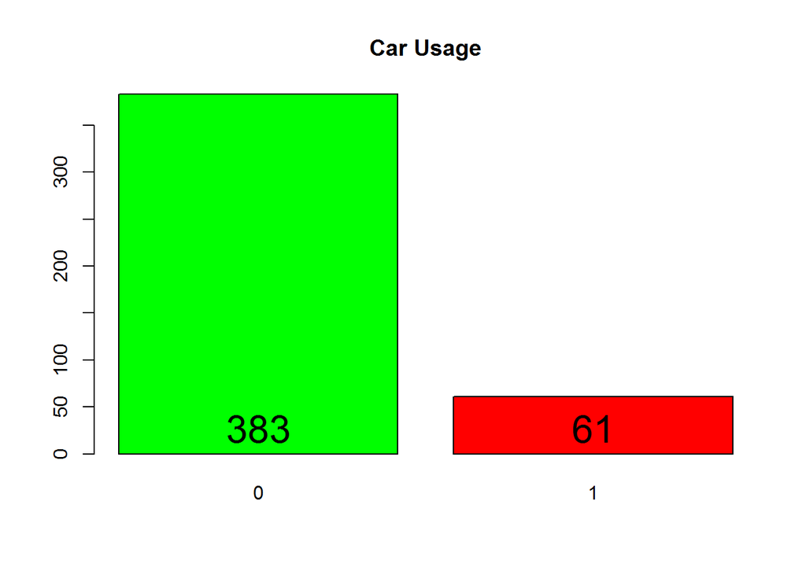

```r
#Plot graph
text(barplot(table(employInfo$CarUsage),col=c('green','red'),main='Car Usage')
     ,0,table(employInfo$CarUsage),cex=2,pos=3)
```

```r
#Check percentage of employs using cars
prop.table(table(employInfo$CarUsage))
```

```
##
##         0         1
## 0.8626126 0.1373874
```

61 out of 444 employs use Car as means of transport. 383 employs use other means of transport. So, 13.73% employs use car and 86.26% use other means of transport.

Check the structure of data frame and convert CarUsage column as factor. Also see the summary.

```r
str(employInfo)
```

```
## 'data.frame':    444 obs. of  10 variables:
##  $ Age      : int  28 23 29 28 27 26 28 26 22 27 ...
##  $ Gender   : Factor w/ 2 levels "Female","Male": 2 1 2 1 2 2 2 1 2 2 ...
##  $ Engineer : Factor w/ 2 levels "0","1": 1 2 2 2 2 2 2 2 2 2 ...
##  $ MBA      : Factor w/ 2 levels "0","1": 1 1 1 2 1 1 1 1 1 1 ...
##  $ Work.Exp : int  4 4 7 5 4 4 5 3 1 4 ...
##  $ Salary   : num  14.3 8.3 13.4 13.4 13.4 12.3 14.4 10.5 7.5 13.5 ...
##  $ Distance : num  3.2 3.3 4.1 4.5 4.6 4.8 5.1 5.1 5.1 5.2 ...
##  $ license  : Factor w/ 2 levels "0","1": 1 1 1 1 1 2 1 1 1 1 ...
##  $ Transport: Factor w/ 3 levels "2Wheeler","Car",..: 3 3 3 3 3 3 1 3 3 3 ...
##  $ CarUsage : num  0 0 0 0 0 0 0 0 0 0 ...
```

```r
#Convert CarUsage to factor
employInfo$CarUsage <- as.factor(employInfo$CarUsage)

#Check the summary
summary(employInfo)
```

```
##       Age           Gender    Engineer MBA        Work.Exp        Salary
##  Min.   :18.00   Female:128   0:109    0:332   Min.   : 0.0   Min.   : 6.50
##  1st Qu.:25.00   Male  :316   1:335    1:112   1st Qu.: 3.0   1st Qu.: 9.80
##  Median :27.00                                 Median : 5.0   Median :13.60
##  Mean   :27.75                                 Mean   : 6.3   Mean   :16.24
##  3rd Qu.:30.00                                 3rd Qu.: 8.0   3rd Qu.:15.72
##  Max.   :43.00                                 Max.   :24.0   Max.   :57.00
##     Distance     license            Transport   CarUsage
##  Min.   : 3.20   0:340   2Wheeler        : 83   0:383
##  1st Qu.: 8.80   1:104   Car             : 61   1: 61
##  Median :11.00           Public Transport:300
##  Mean   :11.32
##  3rd Qu.:13.43
##  Max.   :23.40
```

Check the correlations between variables.

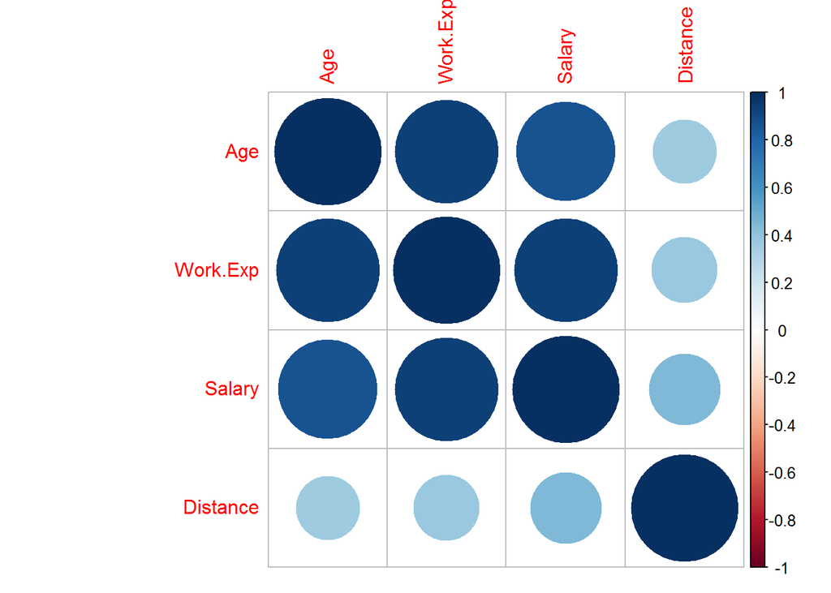

```r
corelemployInfo<-cor(employInfo[sapply(employInfo, is.numeric)])
corrplot(corelemployInfo,method ="circle")
```

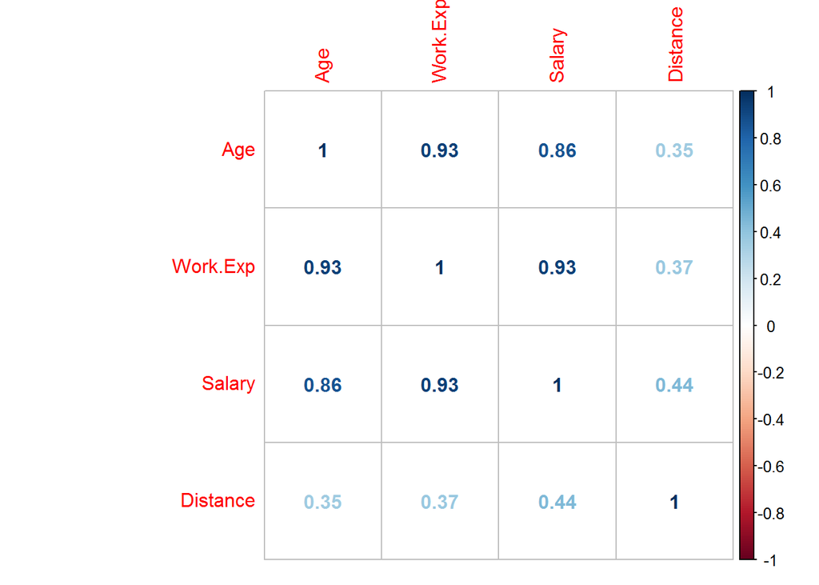

```r
corrplot(corelemployInfo,method ="number")
```

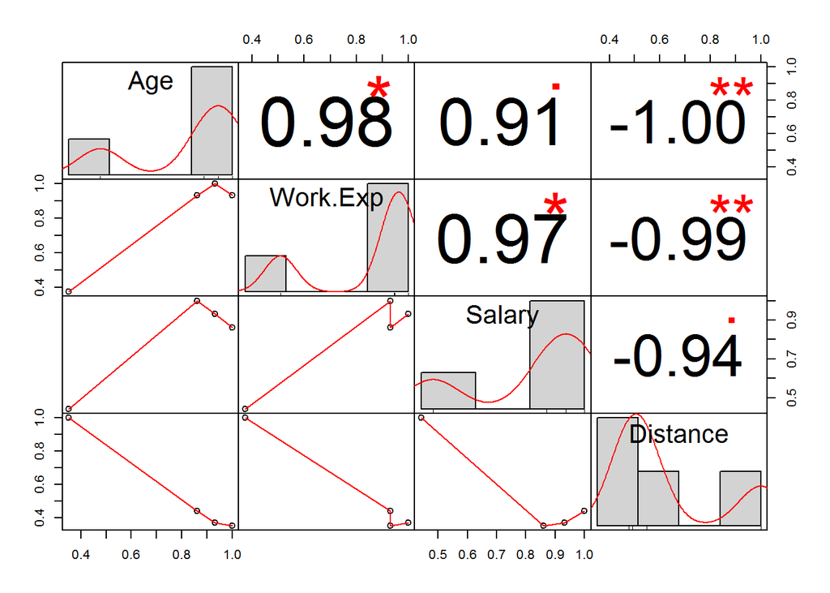

```r
chart.Correlation(corelemployInfo, histogram=TRUE, pch=19)
```

**Predict Car Usage**

Partition the given data into train (70%) and test (30%). Check the car usage in the datasets to understand if the data is split proportionally.

```r
#Partition the data in to train(70%) and test(30%)
set.seed(100)
index    <- createDataPartition(employInfo$CarUsage, p = 0.7, list = FALSE)
employInfotrain <- employInfo[index, ]
employInfotest  <- employInfo[-index, ]

#Check proportion of car usage in the datasets
prop.table(table(employInfotrain$CarUsage))
```

```
##
##         0         1
## 0.8621795 0.1378205
```

```r
prop.table(table(employInfotest$CarUsage))
```

```
##
##         0         1
## 0.8636364 0.1363636
```

```r
prop.table(table(employInfo$CarUsage))
```

```
##
##         0         1
## 0.8626126 0.1373874
```

The train and test data have almost same percentage of cars usage as the base data. All are around 13.7%

Exclude the Transport column from the datasets as we have to do predictions on that column only.

```r
#See column names
colnames(employInfotrain)
```

```
##  [1] "Age"       "Gender"    "Engineer"  "MBA"       "Work.Exp"  "Salary"
##  [7] "Distance"  "license"   "Transport" "CarUsage"
```

```r
#Do not consider the Transport column to build model as it has to be predicted
employInfotrain<-employInfotrain[,c(1:8,10)]
employInfotest<-employInfotest[,c(1:8,10)]

#See column names
colnames(employInfotrain)
```

```
## [1] "Age"      "Gender"   "Engineer" "MBA"      "Work.Exp" "Salary"   "Distance"
## [8] "license"  "CarUsage"
```

**Logistic Regression**

Apply SMOTE on Training data set and use the Logistic regression on the SMOTE data to understand the factors influencing car usage. Since we have only limited variable, we will use all of them in model building. Create control parameter for GLM and use it.

```r
#Apply SMOTE on Training data set
attach(employInfotrain)
employInfoSMOTE<-SMOTE(CarUsage~., employInfotrain, perc.over = 250,perc.under = 150)
prop.table(table(employInfoSMOTE$CarUsage))
```

```
##
##   0   1
## 0.5 0.5
```

```r
#We now have an equal split in the data between car users and non car users.
#Apply SMOTE on Training data set and use the Logistic regression on the SMOTE data to understand the factors influencing car usage.
#Since we have only limited variable, we will use all of them in model building. Create control parameter for GLM and use it.
outcomeVariable<-'CarUsage'
regressors<-c("Age","Work.Exp","Salary","Distance","license","Engineer","MBA","Gender")
trainctrl<-trainControl(method = 'repeatedcv',number = 10,repeats = 3)
employTransportGLM<-train(employInfoSMOTE[,regressors],employInfoSMOTE[,outcomeVariable],method = "glm", family = "binomial",trControl = trainctrl)
```

[output not shown]

See the warnings.

```r
warnings()
```

[output not shown]

See summary of model and plot the importance of variables.

```r
summary(employTransportGLM$finalModel)
```

```
##
## Call:
## NULL
##
## Deviance Residuals:
##     Min       1Q   Median       3Q      Max
## -3.4928  -0.0008   0.0000   0.0012   1.6721
##
## Coefficients:
##              Estimate Std. Error z value Pr(>|z|)
## (Intercept) -115.0450    31.7493  -3.624 0.000291 ***
## Age            3.8737     1.0735   3.609 0.000308 ***
## Work.Exp      -1.5539     0.5609  -2.770 0.005600 **
## Salary         0.1849     0.1062   1.741 0.081651 .
## Distance       0.3708     0.2524   1.469 0.141892
## license1       4.0525     1.5654   2.589 0.009632 **
## Engineer1      0.1574     1.1949   0.132 0.895180
## MBA1          -0.3887     1.0403  -0.374 0.708676
## GenderMale    -2.7021     1.2904  -2.094 0.036259 *
## ---
## Signif. codes:  0 '***' 0.001 '**' 0.01 '*' 0.05 '.' 0.1 ' ' 1
##
## (Dispersion parameter for binomial family taken to be 1)
##
##     Null deviance: 357.664  on 257  degrees of freedom
## Residual deviance:  34.431  on 249  degrees of freedom
## AIC: 52.431
##
## Number of Fisher Scoring iterations: 10
```

```r
#Importance of variables
varImp(object = employTransportGLM)
```

```
## glm variable importance
##
##            Overall
## Age        100.000
## Work.Exp    75.890
## license1    70.669
## GenderMale  56.438
## Salary      46.290
## Distance    38.456
## MBA1         6.957
## Engineer1    0.000
```

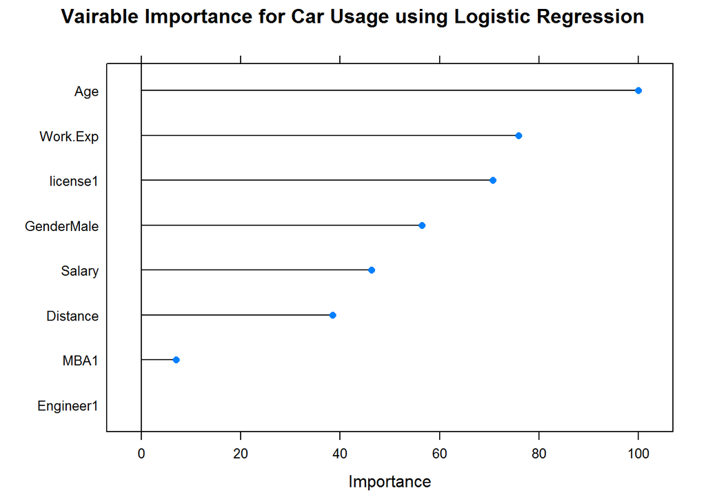

```r
plot(varImp(object = employTransportGLM), main="Vairable Importance for Car Usage using Logistic Regression")
```

Predict car usage on test data using model built and measure the accuracy of model using confusion matrix.

```r
#Predict on test
carUsagePrediction<-predict.train(object = employTransportGLM,employInfotest[,regressors],type = "raw")

carUsageEmployInfoTest<-employInfotest
carUsageEmployInfoTest$PredictCarUsage<-carUsagePrediction
carUsageEmployInfoTest$PredictCarUsage
```

```
##   [1] 0 0 0 0 0 0 0 0 0 0 0 0 0 0 0 0 1 0 0 0 0 0 0 0 0 0 0 0 0 0 0 0 0 0 0 0 0
##  [38] 0 0 0 0 0 0 0 0 0 0 0 0 0 0 0 0 0 0 0 0 0 0 0 0 0 0 0 0 1 1 0 0 0 0 1 0 0
##  [75] 0 0 0 1 0 0 0 1 0 1 0 0 0 0 0 0 0 0 0 0 0 0 1 0 0 0 0 0 0 1 1 0 1 1 1 0 0
## [112] 0 0 1 0 0 0 0 0 0 0 0 0 1 0 1 0 0 1 0 1 0
## Levels: 0 1
```

```r
#Measure accuracy
confusionMatrix(carUsagePrediction,employInfotest[,outcomeVariable], positive='1')
```

```
## Confusion Matrix and Statistics
##
##           Reference
## Prediction   0   1
##          0 111   3
##          1   3  15
##
##                Accuracy : 0.9545
##                  95% CI : (0.9037, 0.9831)
##     No Information Rate : 0.8636
##     P-Value [Acc > NIR] : 0.0005559
##
##                   Kappa : 0.807
##
##  Mcnemar's Test P-Value : 1.0000000
##
##             Sensitivity : 0.8333
##             Specificity : 0.9737
##          Pos Pred Value : 0.8333
##          Neg Pred Value : 0.9737
##              Prevalence : 0.1364
##          Detection Rate : 0.1136
##    Detection Prevalence : 0.1364
##       Balanced Accuracy : 0.9035
##
##        'Positive' Class : 1
##
```

Predict the car usage for given two records where transport is unknown using GLM model.

```r
#Predict the car usage for given two records where transport is unknown
#Get the two records with unknown transport in to data frame.
employInfoWithUnknownTransport<-read.csv("EmployInfoWithUnknownTransport.csv", header = TRUE)

#Convert license,Engineer,MBA to factors
employInfoWithUnknownTransport$license<-as.factor(employInfoWithUnknownTransport$license)
employInfoWithUnknownTransport$Engineer<-as.factor(employInfoWithUnknownTransport$Engineer)
employInfoWithUnknownTransport$MBA<-as.factor(employInfoWithUnknownTransport$MBA)

#Predict car usage
employInfoWithUnknownTransport$CarUsagePredictionGLM<-predict.train(object = employTransportGLM,employInfoWithUnknownTransport[,regressors],type = "raw")

#Print output to see predictions
print(employInfoWithUnknownTransport)
```

```
##   Age Gender Engineer MBA Work.Exp Salary Distance license
## 1  25   Male        0   0        2     10        5       1
## 2  25 Female        1   0        2     10        5       0
##   CarUsagePredictionGLM
## 1                     0
## 2                     0
```

The two employs do not use car as means of transport as per the GLM model built.

**Ridge Regression**

Use glmnet method of caret package and run Ridge Regression Model to predict car usage in another way.

```r
#Using glmnet method of caret package to try and run Ridge Regression Model
trainctrlgn<-trainControl(method = 'cv',number = 10,returnResamp = 'none')
employTransportGLMnet<-train(CarUsage~Age+Work.Exp+Salary+Distance+license, data = employInfoSMOTE, method = 'glmnet', trControl = trainctrlgn)
employTransportGLMnet
```

```
## glmnet
##
## 258 samples
##   5 predictor
##   2 classes: '0', '1'
##
## No pre-processing
## Resampling: Cross-Validated (10 fold)
## Summary of sample sizes: 232, 232, 233, 232, 232, 232, ...
## Resampling results across tuning parameters:
##
##   alpha  lambda        Accuracy   Kappa
##   0.10   0.0008311143  0.9533846  0.9066016
##   0.10   0.0083111431  0.9380000  0.8758324
##   0.10   0.0831114311  0.9184615  0.8366256
##   0.55   0.0008311143  0.9495385  0.8989093
##   0.55   0.0083111431  0.9456923  0.8912170
##   0.55   0.0831114311  0.9300000  0.8597025
##   1.00   0.0008311143  0.9573846  0.9146402
##   1.00   0.0083111431  0.9535385  0.9069479
##   1.00   0.0831114311  0.9495385  0.8989612
##
## Accuracy was used to select the optimal model using the largest value.
## The final values used for the model were alpha = 1 and lambda = 0.0008311143.
```

```r
#Predict on test
carUsagePredictionGnet<-predict.train(object = employTransportGLMnet,employInfotest[,regressors],type = "raw")

#Check accuracy
confusionMatrix(carUsagePredictionGnet,employInfotest[,outcomeVariable], positive='1')
```

```
## Confusion Matrix and Statistics
##
##           Reference
## Prediction   0   1
##          0 108   4
##          1   6  14
##
##                Accuracy : 0.9242
##                  95% CI : (0.8651, 0.9631)
##     No Information Rate : 0.8636
##     P-Value [Acc > NIR] : 0.02244
##
##                   Kappa : 0.6927
##
##  Mcnemar's Test P-Value : 0.75183
##
##             Sensitivity : 0.7778
##             Specificity : 0.9474
##          Pos Pred Value : 0.7000
##          Neg Pred Value : 0.9643
##              Prevalence : 0.1364
##          Detection Rate : 0.1061
##    Detection Prevalence : 0.1515
##       Balanced Accuracy : 0.8626
##
##        'Positive' Class : 1
##
```

Check the importance of variables.

```r
varImp(object = employTransportGLMnet)
```

```
## glmnet variable importance
##
##          Overall
## license1  100.00
## Age        98.42
## Work.Exp   32.61
## Distance   10.59
## Salary      0.00
```

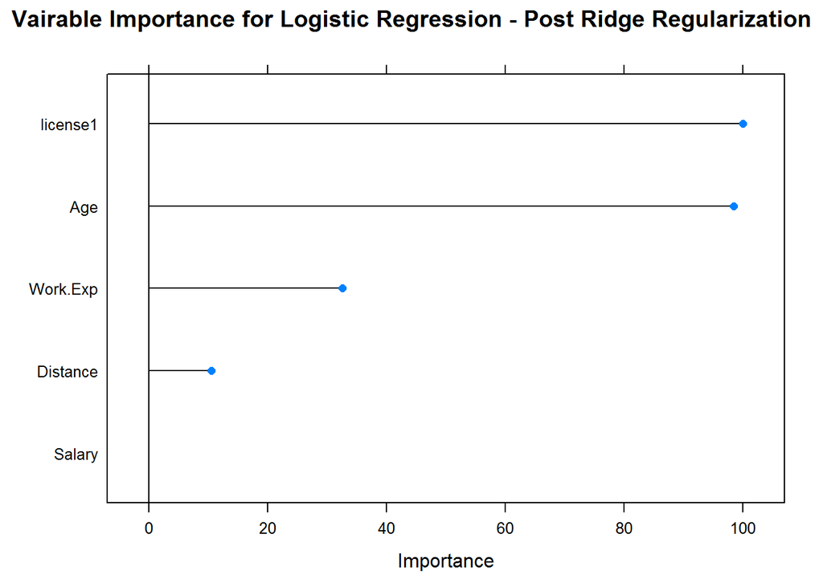

```r
plot(varImp(object = employTransportGLMnet), main="Vairable Importance for Logistic Regression - Post Ridge Regularization")
```

Age, Work Experience, license is very important as per Ridge Regression.

Predict the car usage for given two records where transport is unknown using GLMnet model.

```r
employInfoWithUnknownTransport$CarUsagePredictionGLMnet<-predict.train(object = employTransportGLMnet,employInfoWithUnknownTransport[,regressors],type = "raw")
print(employInfoWithUnknownTransport)
```

```
##   Age Gender Engineer MBA Work.Exp Salary Distance license
## 1  25   Male        0   0        2     10        5       1
## 2  25 Female        1   0        2     10        5       0
##   CarUsagePredictionGLM CarUsagePredictionGLMnet
## 1                     0                        0
## 2                     0                        0
```

The two employs do not use car as means of transport as per the GLMnet model built.

## Predict Choice of Transport

**LDA**

Get the given records into a new data frame. Convert required to factors and impute the missing values. Then split the data into test and train samples.

```r
##Split the original base data into test and train samples again

#Read data
employInfoLDA<-read.csv("Cars.csv", header = TRUE)

#convert required variables to factors
employInfoLDA$Gender<-as.factor(employInfoLDA$Gender)
employInfoLDA$Engineer<-as.factor(employInfoLDA$Engineer)
employInfoLDA$MBA<-as.factor(employInfoLDA$MBA)

#Impute missing values
employInfoLDA<-knnImputation(employInfoLDA)

#Set seed
set.seed(100)

#Split data in to train and test datasets
employInfoLDA_Index<-createDataPartition(employInfoLDA$Transport, p=0.7,list = FALSE,times = 1)
employInfoLDA_Train<-employInfoLDA[employInfoLDA_Index,]
employInfoLDA_Test<-employInfoLDA[-employInfoLDA_Index,]
```

Get required values and do conversions in train and test. Check the proportion of cars and two wheelers when compared to public transport.

```r
#Get required values and do conversions in train and test
employInfoLDA_Train$license<-as.factor(employInfoLDA_Train$license)
employInfoLDA_Test$license<-as.factor(employInfoLDA_Test$license)
employInfoLDA_Train_Car<-employInfoLDA_Train[employInfoLDA_Train$Transport %in% c("Car", "Public Transport"),]
employInfoLDA_Train_2Wheeler<-employInfoLDA_Train[employInfoLDA_Train$Transport %in% c("2Wheeler", "Public Transport"),]
employInfoLDA_Train_Car$Transport<-as.character(employInfoLDA_Train_Car$Transport)
employInfoLDA_Train_Car$Transport<-as.factor(employInfoLDA_Train_Car$Transport)
employInfoLDA_Train_2Wheeler$Transport<-as.character(employInfoLDA_Train_2Wheeler$Transport)
employInfoLDA_Train_2Wheeler$Transport<-as.factor(employInfoLDA_Train_2Wheeler$Transport)

#Check proportions
prop.table(table(employInfoLDA_Train_Car$Transport))
```

```
##
##              Car Public Transport
##        0.1699605        0.8300395
```

```r
prop.table(table(employInfoLDA_Train_2Wheeler$Transport))
```

```
##
##         2Wheeler Public Transport
##        0.2193309        0.7806691
```

When we consider a dataset with cars and public transport, 16.99% use cars and 83% use public transport. When we consider a dataset with 2wheelers and public transport, 21.93% use 2wheelers and 78% use public transport.

Use smote to balance proportions in the datasets.

```r
#Use SMOTE on each dataset and combine both datasets
employInfoLDA_2Wheeeler_SM <- SMOTE(Transport~., data = employInfoLDA_Train_2Wheeler, perc.over = 150, perc.under=200)
table(employInfoLDA_2Wheeeler_SM$Transport)
```

```
##
##         2Wheeler Public Transport
##              118              118
```

```r
employInfoLDA_Car_SM <- SMOTE(Transport~., data = employInfoLDA_Train_Car, perc.over = 175, perc.under=200)
table(employInfoLDA_Car_SM$Transport)
```

```
##
##              Car Public Transport
##               86               86
```

```r
employInfoLDA_Car<-employInfoLDA_Car_SM[employInfoLDA_Car_SM$Transport %in% c("Car"),]
employInfotrainldasm<-rbind(employInfoLDA_2Wheeeler_SM,employInfoLDA_Car)
str(employInfotrainldasm)
```

```
## 'data.frame':    322 obs. of  9 variables:
##  $ Age      : num  26 36 26 26 34 30 27 28 27 26 ...
##  $ Gender   : Factor w/ 2 levels "Female","Male": 2 2 2 2 2 2 2 2 1 2 ...
##  $ Engineer : Factor w/ 2 levels "0","1": 1 2 2 2 2 1 2 2 2 2 ...
##  $ MBA      : Factor w/ 2 levels "0","1": 1 2 1 1 1 2 1 1 2 2 ...
##  $ Work.Exp : num  4 16 3 5 13 7 4 5 4 7 ...
##  $ Salary   : num  12.6 34.8 10.7 11.4 16.5 14.4 13.8 13.8 13.8 20.9 ...
##  $ Distance : num  11.5 9.2 12.2 6.1 5.9 7.3 12.4 15.5 9.8 11.6 ...
##  $ license  : Factor w/ 2 levels "0","1": 2 1 2 1 1 1 1 1 1 1 ...
##  $ Transport: Factor w/ 3 levels "2Wheeler","Public Transport",..: 2 2 2 2 2 2 2 2 2 2 ...
```

```r
table(employInfotrainldasm$Transport)
```

```
##
##         2Wheeler Public Transport              Car
##              118              118               86
```

Now the train dataset has 118 employs using two wheelers, 118 employs using public transport and 86 employs using cars.

Build LDA model and check importance of variables.

```r
#Build LDA model and check of importance of variables
attach(employInfotrainldasm)
trainctrllda<-trainControl(method = 'cv',number = 10)
employTransport_LDA<-train(Transport~Age+Work.Exp+Salary+Distance+license+Gender+Engineer+MBA ,data = employInfotrainldasm, method="lda", trControl=trainctrllda)
employTransport_LDA$finalModel
```

```
## Call:
## lda(x, grouping = y)
##
## Prior probabilities of groups:
##         2Wheeler Public Transport              Car
##        0.3664596        0.3664596        0.2670807
##
## Group means:
##                       Age  Work.Exp   Salary Distance   license1 GenderMale
## 2Wheeler         25.24537  4.015086 12.53699 12.07805 0.32203390  0.5677966
## Public Transport 27.36441  5.567797 14.31356 10.71949 0.09322034  0.6610169
## Car              35.72756 15.890898 36.69666 15.37530 0.74418605  0.7790698
##                  Engineer1      MBA1
## 2Wheeler         0.6949153 0.3050847
## Public Transport 0.7288136 0.3220339
## Car              0.8837209 0.1511628
##
## Coefficients of linear discriminants:
##                     LD1         LD2
## Age         0.210979468 -0.42389048
## Work.Exp   -0.063116761  0.19833738
## Salary      0.072025124  0.02072611
## Distance    0.060024179  0.14759867
## license1    0.352793800  1.60271357
## GenderMale  0.099988023 -0.50003169
## Engineer1   0.007827268  0.08230623
## MBA1       -0.425712077 -0.19327102
##
## Proportion of trace:
##    LD1    LD2
## 0.9046 0.0954
```

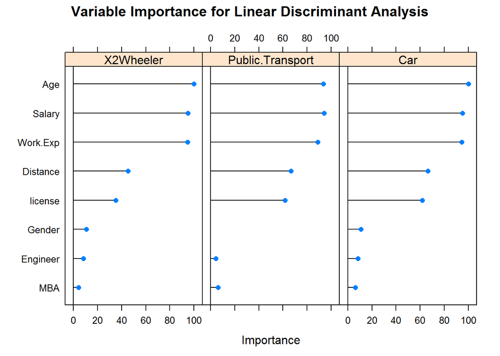

```r
#Plot importance of variables
plot(varImp(object = employTransport_LDA),main="Variable Importance for Linear Discriminant Analysis" )
```

Age, Work Experience, Salary and Distance are critical parameters that decide means of transport as per above plots.

Predict on the test dataset and check accuracy of model.

```r
#Predict on the test dataset and check accuracy of model
colnames(employInfoLDA_Test)
```

```
## [1] "Age"       "Gender"    "Engineer"  "MBA"       "Work.Exp"  "Salary"
## [7] "Distance"  "license"   "Transport"
```

```r
employTransport_LDA_Predict<-predict.train(object = employTransport_LDA,newdata = employInfoLDA_Test)
confusionMatrix(employTransport_LDA_Predict,employInfoLDA_Test[,9])
```

```
## Confusion Matrix and Statistics
##
##                   Reference
## Prediction         2Wheeler Car Public Transport
##   2Wheeler               20   1               25
##   Car                     0  11                0
##   Public Transport        4   6               65
##
## Overall Statistics
##
##                Accuracy : 0.7273
##                  95% CI : (0.6429, 0.8011)
##     No Information Rate : 0.6818
##     P-Value [Acc > NIR] : 0.1518
##
##                   Kappa : 0.493
##
##  Mcnemar's Test P-Value : 5.907e-05
##
## Statistics by Class:
##
##                      Class: 2Wheeler Class: Car Class: Public Transport
## Sensitivity                   0.8333    0.61111                  0.7222
## Specificity                   0.7593    1.00000                  0.7619
## Pos Pred Value                0.4348    1.00000                  0.8667
## Neg Pred Value                0.9535    0.94215                  0.5614
## Prevalence                    0.1818    0.13636                  0.6818
## Detection Rate                0.1515    0.08333                  0.4924
## Detection Prevalence          0.3485    0.08333                  0.5682
## Balanced Accuracy             0.7963    0.80556                  0.7421
```

Predict on the means of transport for employs with unknown transport.

```r
predictTransportUnknown_LDA<-predict.train(object = employTransport_LDA,newdata = employInfoWithUnknownTransport)
employInfoWithUnknownTransport$TransportUsageLDA<-predictTransportUnknown_LDA#change this col name as rel like predictcaruselda
print(employInfoWithUnknownTransport)
```

```
##   Age Gender Engineer MBA Work.Exp Salary Distance license
## 1  25   Male        0   0        2     10        5       1
## 2  25 Female        1   0        2     10        5       0
##   CarUsagePredictionGLM CarUsagePredictionGLMnet TransportUsageLDA
## 1                     0                        0          2Wheeler
## 2                     0                        0  Public Transport
```

As per the LDA model built, the two employs use 2 wheeler and public transport respectively.

**PDA**

Build PDA model for making predictions and plot variable importance.

```r
#Improve LDA Model by Regularization
#Try and run penalised LDA for the model above

trainctrlpda<-trainControl(method = 'cv',number = 10, returnResamp = 'all')
employTransport_PDA<-train(Transport~Age+Work.Exp+Salary+Distance+license+Gender+Engineer+MBA ,data = employInfotrainldasm, method="pda", trControl=trainctrlpda)
employTransport_PDA$finalModel
```

```
## Call:
## mda::fda(formula = as.formula(".outcome ~ ."), data = dat, method = mda::gen.ridge,
##     lambda = param$lambda)
##
## Dimension: 2
##
## Percent Between-Group Variance Explained:
##     v1     v2
##  90.46 100.00
##
## Degrees of Freedom (per dimension): 9
##
## Training Misclassification Error: 0.24534 ( N = 322 )
```

```r
employTransport_PDA
```

```
## Penalized Discriminant Analysis
##
## 322 samples
##   8 predictor
##   3 classes: '2Wheeler', 'Public Transport', 'Car'
##
## No pre-processing
## Resampling: Cross-Validated (10 fold)
## Summary of sample sizes: 289, 289, 292, 290, 289, 289, ...
## Resampling results across tuning parameters:
##
##   lambda  Accuracy   Kappa
##   0e+00   0.7289088  0.5875877
##   1e-04   0.7289088  0.5875877
##   1e-01   0.7289088  0.5875877
##
## Accuracy was used to select the optimal model using the largest value.
## The final value used for the model was lambda = 0.
```

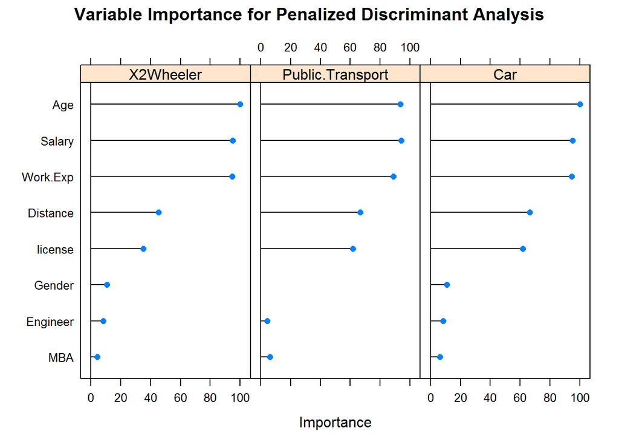

```r
#Plot variable importance
plot(varImp(object = employTransport_PDA), main="Variable Importance for Penalized Discriminant Analysis")
```

Here also Age, Work Experience, Salary and Distance are very important variables asper the plots drawn.

Predict on test dataset and check accuracy.

```r
#Predict on test dataset and check accuracy
employTransport_PDA_Predict<-predict.train(object = employTransport_PDA,newdata = employInfoLDA_Test)
confusionMatrix(employTransport_PDA_Predict,employInfoLDA_Test[,9])
```

```
## Confusion Matrix and Statistics
##
##                   Reference
## Prediction         2Wheeler Car Public Transport
##   2Wheeler               20   1               25
##   Car                     0  11                0
##   Public Transport        4   6               65
##
## Overall Statistics
##
##                Accuracy : 0.7273
##                  95% CI : (0.6429, 0.8011)
##     No Information Rate : 0.6818
##     P-Value [Acc > NIR] : 0.1518
##
##                   Kappa : 0.493
##
##  Mcnemar's Test P-Value : 5.907e-05
##
## Statistics by Class:
##
##                      Class: 2Wheeler Class: Car Class: Public Transport
## Sensitivity                   0.8333    0.61111                  0.7222
## Specificity                   0.7593    1.00000                  0.7619
## Pos Pred Value                0.4348    1.00000                  0.8667
## Neg Pred Value                0.9535    0.94215                  0.5614
## Prevalence                    0.1818    0.13636                  0.6818
## Detection Rate                0.1515    0.08333                  0.4924
## Detection Prevalence          0.3485    0.08333                  0.5682
## Balanced Accuracy             0.7963    0.80556                  0.7421
```

Predict means of transport for the two unknown cases with above model.

```r
predictTransportUnknown_PDA<-predict.train(object = employTransport_PDA,newdata = employInfoWithUnknownTransport)
employInfoWithUnknownTransport$TransportUsagePDA<-predictTransportUnknown_PDA
print(employInfoWithUnknownTransport)
```

```
##   Age Gender Engineer MBA Work.Exp Salary Distance license
## 1  25   Male        0   0        2     10        5       1
## 2  25 Female        1   0        2     10        5       0
##   CarUsagePredictionGLM CarUsagePredictionGLMnet TransportUsageLDA
## 1                     0                        0          2Wheeler
## 2                     0                        0  Public Transport
##   TransportUsagePDA
## 1          2Wheeler
## 2  Public Transport
```

As per the PDA model built, the two employs use 2 wheeler and public transport respectively.

**CART**

Train the model using CART and see the tree.

```r
#Train the model using CART
TransportUsageCART<-train(Transport~.,employInfotrainldasm,method = 'rpart', trControl = trainControl(method = 'cv',number = 5,savePredictions = 'final'))
TransportUsageCART$finalModel
```

```
## n= 322
##
## node), split, n, loss, yval, (yprob)
##       * denotes terminal node
##
## 1) root 322 204 2Wheeler (0.366459627 0.366459627 0.267080745)
##   2) Age< 30.05611 220 105 2Wheeler (0.522727273 0.468181818 0.009090909) *
##   3) Age>=30.05611 102  18 Car (0.029411765 0.147058824 0.823529412) *
```

[figure not shown]

```r
fancyRpartPlot(TransportUsageCART$finalModel)
```

Predict on test dataset and check accuracy.

```r
predictions_CART<-predict(TransportUsageCART,employInfoLDA_Test)
confusionMatrix(predictions_CART,employInfoLDA_Test$Transport)
```

```
## Confusion Matrix and Statistics
##
##                   Reference
## Prediction         2Wheeler Car Public Transport
##   2Wheeler               24   0               86
##   Car                     0  18                4
##   Public Transport        0   0                0
##
## Overall Statistics
##
##                Accuracy : 0.3182
##                  95% CI : (0.2399, 0.4049)
##     No Information Rate : 0.6818
##     P-Value [Acc > NIR] : 1
##
##                   Kappa : 0.1743
##
##  Mcnemar's Test P-Value : NA
##
## Statistics by Class:
##
##                      Class: 2Wheeler Class: Car Class: Public Transport
## Sensitivity                   1.0000     1.0000                  0.0000
## Specificity                   0.2037     0.9649                  1.0000
## Pos Pred Value                0.2182     0.8182                     NaN
## Neg Pred Value                1.0000     1.0000                  0.3182
## Prevalence                    0.1818     0.1364                  0.6818
## Detection Rate                0.1818     0.1364                  0.0000
## Detection Prevalence          0.8333     0.1667                  0.0000
## Balanced Accuracy             0.6019     0.9825                  0.5000
```

Predict the two unknown cases.

```r
predictTransportUnknown_CART<-predict.train(object = TransportUsageCART,newdata = employInfoWithUnknownTransport)
employInfoWithUnknownTransport$TransportUsageCART<-predictTransportUnknown_CART
print(employInfoWithUnknownTransport)
```

```
##   Age Gender Engineer MBA Work.Exp Salary Distance license
## 1  25   Male        0   0        2     10        5       1
## 2  25 Female        1   0        2     10        5       0
##   CarUsagePredictionGLM CarUsagePredictionGLMnet TransportUsageLDA
## 1                     0                        0          2Wheeler
## 2                     0                        0  Public Transport
##   TransportUsagePDA TransportUsageCART
## 1          2Wheeler           2Wheeler
## 2  Public Transport           2Wheeler
```

As per the CART model built, both the employs use 2 wheeler as means of transport.

**Boosting**

Build a model using boosting.

```r
#Build model using Boosting
boostcontrol <- trainControl(number=10)

xgbGrid <- expand.grid(
  eta = 0.3,
  max_depth = 1,
  nrounds = 50,
  gamma = 0,
  colsample_bytree = 0.6,
  min_child_weight = 1, subsample = 1
)

TransportUsageXGB <-  train(Transport ~ .,employInfotrainldasm,trControl = boostcontrol,tuneGrid = xgbGrid,metric = "Accuracy",method = "xgbTree")
TransportUsageXGB$finalModel
```

```
## ##### xgb.Booster
## raw: 38.5 Kb
## call:
##   xgboost::xgb.train(params = list(eta = param$eta, max_depth = param$max_depth,
##     gamma = param$gamma, colsample_bytree = param$colsample_bytree,
##     min_child_weight = param$min_child_weight, subsample = param$subsample),
##     data = x, nrounds = param$nrounds, num_class = length(lev),
##     objective = "multi:softprob")
## params (as set within xgb.train):
##   eta = "0.3", max_depth = "1", gamma = "0", colsample_bytree = "0.6", min_child_weight = "1", subsample = "1", num_class = "3", objective = "multi:softprob", silent = "1"
## xgb.attributes:
##   niter
## callbacks:
##   cb.print.evaluation(period = print_every_n)
## # of features: 8
## niter: 50
## nfeatures : 8
## xNames : Age GenderMale Engineer1 MBA1 Work.Exp Salary Distance license1
## problemType : Classification
## tuneValue :
##    nrounds max_depth eta gamma colsample_bytree min_child_weight subsample
## 1      50         1 0.3     0              0.6                1         1
## obsLevels : 2Wheeler Public Transport Car
## param :
##  list()
```

Predict using the test dataset and check accuracy.

```r
predictions_xgb<-predict(TransportUsageXGB,employInfoLDA_Test)
confusionMatrix(predictions_xgb,employInfoLDA_Test$Transport)
```

```
## Confusion Matrix and Statistics
##
##                   Reference
## Prediction         2Wheeler Car Public Transport
##   2Wheeler               21   0               25
##   Car                     0  16                0
##   Public Transport        3   2               65
##
## Overall Statistics
##
##                Accuracy : 0.7727
##                  95% CI : (0.6917, 0.8411)
##     No Information Rate : 0.6818
##     P-Value [Acc > NIR] : 0.01394
##
##                   Kappa : 0.5931
##
##  Mcnemar's Test P-Value : NA
##
## Statistics by Class:
##
##                      Class: 2Wheeler Class: Car Class: Public Transport
## Sensitivity                   0.8750     0.8889                  0.7222
## Specificity                   0.7685     1.0000                  0.8810
## Pos Pred Value                0.4565     1.0000                  0.9286
## Neg Pred Value                0.9651     0.9828                  0.5968
## Prevalence                    0.1818     0.1364                  0.6818
## Detection Rate                0.1591     0.1212                  0.4924
## Detection Prevalence          0.3485     0.1212                  0.5303
## Balanced Accuracy             0.8218     0.9444                  0.8016
```

Predict the 2 unknown cases.

```r
predictTransportUnknown_XGB<-predict.train(object = TransportUsageXGB,newdata = employInfoWithUnknownTransport)
employInfoWithUnknownTransport$TransportUsageXGB<-predictTransportUnknown_XGB
print(employInfoWithUnknownTransport)
```

```
##   Age Gender Engineer MBA Work.Exp Salary Distance license
## 1  25   Male        0   0        2     10        5       1
## 2  25 Female        1   0        2     10        5       0
##   CarUsagePredictionGLM CarUsagePredictionGLMnet TransportUsageLDA
## 1                     0                        0          2Wheeler
## 2                     0                        0  Public Transport
##   TransportUsagePDA TransportUsageCART TransportUsageXGB
## 1          2Wheeler           2Wheeler          2Wheeler
## 2  Public Transport           2Wheeler          2Wheeler
```

**Multinomial Logistic Regression**

Build a model to predict transport using MLR.

```r
#Build model using MLR
TransportUsageMLR<-train(Transport ~.,employInfotrainldasm,method = "multinom")
TransportUsageMLR$finalModel
```

```
## Call:
## nnet::multinom(formula = .outcome ~ ., data = dat, decay = param$decay)
##
## Coefficients:
##                  (Intercept)       Age GenderMale  Engineer1       MBA1
## Public Transport   -10.88650 0.5156236 0.79475515 -0.1291903  0.0531713
## Car                -62.80961 2.0702764 0.04713566  0.4431085 -2.5941673
##                    Work.Exp      Salary   Distance   license1
## Public Transport -0.1592692 -0.04283743 -0.1227120 -1.9372057
## Car              -1.2165391  0.20795604  0.4074566  0.7628728
##
## Residual Deviance: 320.7574
## AIC: 356.7574
```

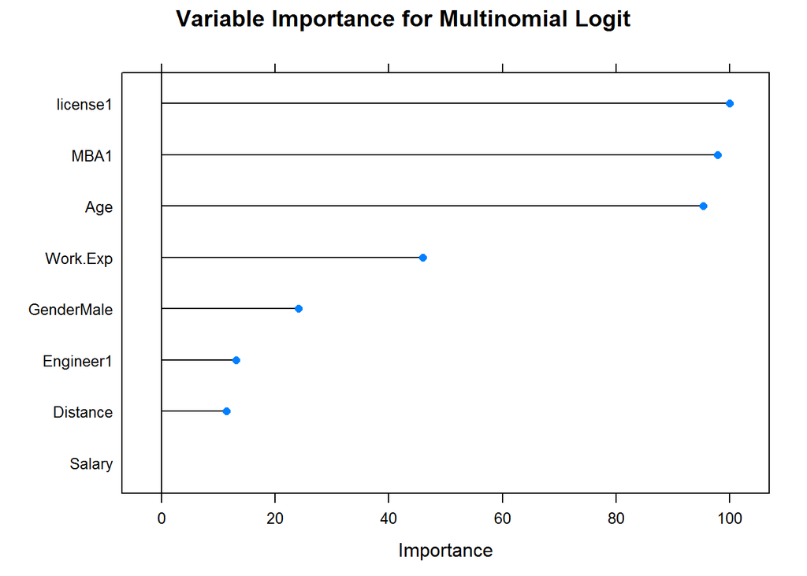

```r
plot(varImp(object=TransportUsageMLR), main = "Variable Importance for Multinomial Logit")
```

Predict using the test dataset and check accuracy.

```r
predictions_mlr<-predict(TransportUsageMLR,employInfoLDA_Test)
confusionMatrix(predictions_mlr,employInfoLDA_Test$Transport)
```

```
## Confusion Matrix and Statistics
##
##                   Reference
## Prediction         2Wheeler Car Public Transport
##   2Wheeler               18   2               26
##   Car                     1  12                0
##   Public Transport        5   4               64
##
## Overall Statistics
##
##                Accuracy : 0.7121
##                  95% CI : (0.6269, 0.7876)
##     No Information Rate : 0.6818
##     P-Value [Acc > NIR] : 0.2587247
##
##                   Kappa : 0.4729
##
##  Mcnemar's Test P-Value : 0.0003372
##
## Statistics by Class:
##
##                      Class: 2Wheeler Class: Car Class: Public Transport
## Sensitivity                   0.7500    0.66667                  0.7111
## Specificity                   0.7407    0.99123                  0.7857
## Pos Pred Value                0.3913    0.92308                  0.8767
## Neg Pred Value                0.9302    0.94958                  0.5593
## Prevalence                    0.1818    0.13636                  0.6818
## Detection Rate                0.1364    0.09091                  0.4848
## Detection Prevalence          0.3485    0.09848                  0.5530
## Balanced Accuracy             0.7454    0.82895                  0.7484
```

Predict the 2 unknown cases using model built.

```r
predictTransportUnknown_MLR<-predict.train(object = TransportUsageMLR,newdata = employInfoWithUnknownTransport)
employInfoWithUnknownTransport$TransportUsageMLR<-predictTransportUnknown_MLR
print(employInfoWithUnknownTransport)
```

```
##   Age Gender Engineer MBA Work.Exp Salary Distance license
## 1  25   Male        0   0        2     10        5       1
## 2  25 Female        1   0        2     10        5       0
##   CarUsagePredictionGLM CarUsagePredictionGLMnet TransportUsageLDA
## 1                     0                        0          2Wheeler
## 2                     0                        0  Public Transport
##   TransportUsagePDA TransportUsageCART TransportUsageXGB TransportUsageMLR
## 1          2Wheeler           2Wheeler          2Wheeler          2Wheeler
## 2  Public Transport           2Wheeler          2Wheeler  Public Transport
```

As per the MLR model built, the two employs use 2 wheeler and public transport respectively.

**Random Forest**

Train the model using Random Forest.

```r
#Train the model using RF
RF_trcontrol<-control <- trainControl(method="repeatedcv", number=10, repeats=3)
mtry<-sqrt(ncol(employInfotrainldasm))
RF_tunegrid <- expand.grid(.mtry=mtry)
TransportUsageRF<-train(Transport ~.,employInfotrainldasm,method = "rf", trControl=RF_trcontrol, tuneGrid = RF_tunegrid)
TransportUsageRF$finalModel
```

```
##
## Call:
##  randomForest(x = x, y = y, mtry = param$mtry)
##                Type of random forest: classification
##                      Number of trees: 500
## No. of variables tried at each split: 3
##
##         OOB estimate of  error rate: 18.32%
## Confusion matrix:
##                  2Wheeler Public Transport Car class.error
## 2Wheeler               87               29   2  0.26271186
## Public Transport       22               94   2  0.20338983
## Car                     1                3  82  0.04651163
```

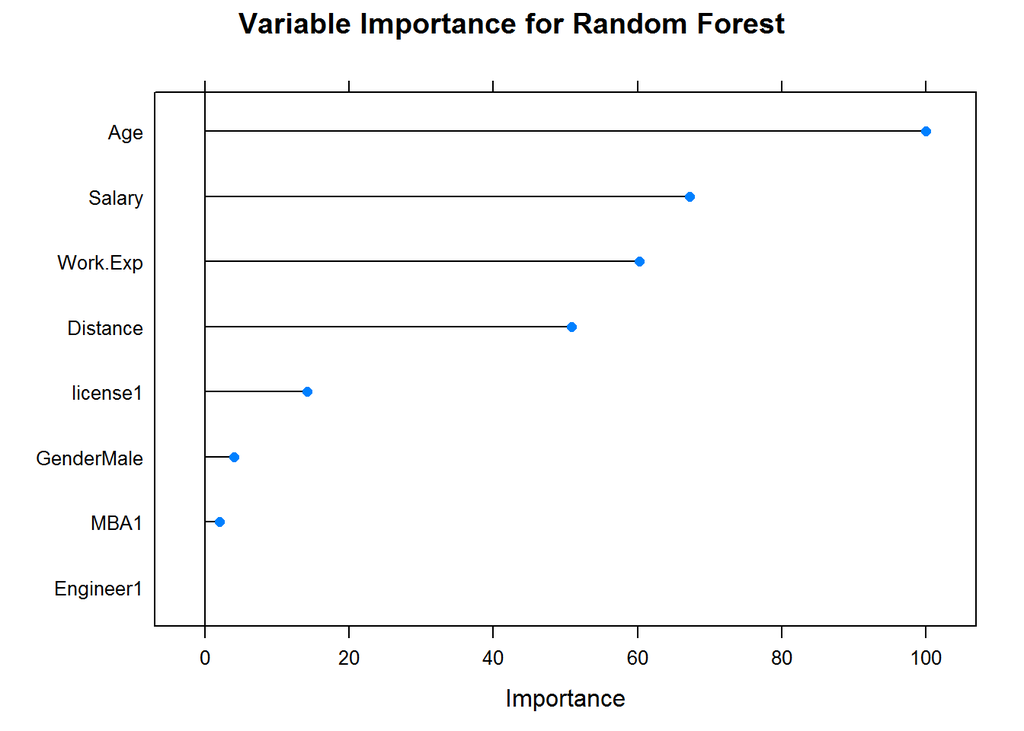

```r
#dev.off()
plot(varImp(object=TransportUsageRF), main = "Variable Importance for Random Forest")
```

Age, Salary, Work Experience, Distance and license are very important variables that are critical in predicting means of transport used by employs.

Predict using the test dataset and check accuracy.

```r
predictions_rf<-predict(TransportUsageRF,employInfoLDA_Test)
confusionMatrix(predictions_rf,employInfoLDA_Test$Transport)
```

```
## Confusion Matrix and Statistics
##
##                   Reference
## Prediction         2Wheeler Car Public Transport
##   2Wheeler               19   0               31
##   Car                     0  17                0
##   Public Transport        5   1               59
##
## Overall Statistics
##
##                Accuracy : 0.7197
##                  95% CI : (0.6349, 0.7943)
##     No Information Rate : 0.6818
##     P-Value [Acc > NIR] : 0.2012
##
##                   Kappa : 0.5149
##
##  Mcnemar's Test P-Value : NA
##
## Statistics by Class:
##
##                      Class: 2Wheeler Class: Car Class: Public Transport
## Sensitivity                   0.7917     0.9444                  0.6556
## Specificity                   0.7130     1.0000                  0.8571
## Pos Pred Value                0.3800     1.0000                  0.9077
## Neg Pred Value                0.9390     0.9913                  0.5373
## Prevalence                    0.1818     0.1364                  0.6818
## Detection Rate                0.1439     0.1288                  0.4470
## Detection Prevalence          0.3788     0.1288                  0.4924
## Balanced Accuracy             0.7523     0.9722                  0.7563
```

Predict the 2 unknown cases.

```r
predictTransportUnknown_RF<-predict.train(object = TransportUsageRF,newdata = employInfoWithUnknownTransport)
employInfoWithUnknownTransport$TransportUsageRF<-predictTransportUnknown_RF
print(employInfoWithUnknownTransport)
```

```
##   Age Gender Engineer MBA Work.Exp Salary Distance license
## 1  25   Male        0   0        2     10        5       1
## 2  25 Female        1   0        2     10        5       0
##   CarUsagePredictionGLM CarUsagePredictionGLMnet TransportUsageLDA
## 1                     0                        0          2Wheeler
## 2                     0                        0  Public Transport
##   TransportUsagePDA TransportUsageCART TransportUsageXGB TransportUsageMLR
## 1          2Wheeler           2Wheeler          2Wheeler          2Wheeler
## 2  Public Transport           2Wheeler          2Wheeler  Public Transport
##   TransportUsageRF
## 1 Public Transport
## 2 Public Transport
```

**Write all predictions to csv**

write.csv(employInfoWithUnknownTransport,file = “PredictionsForUnknownTransport.csv”)

**Conclusion**

Most probably Employ 1 uses Two-Wheeler and Employ 2 uses Public Transport for commuting to office. The chance that any one of them using Car is very less or almost nil as per above predictions.